# Machine Learning 1

Haroon Riyaz (PID A15377799)

2/14/2022

# First: Kmeans()

Demo for using kmeans function in Base R! First make data with known structure!

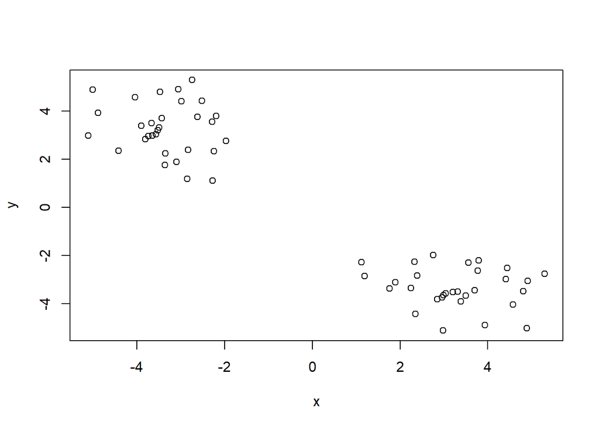

```r
tmp <- c(rnorm(30,-3), rnorm(30,3))
x <- cbind(x=tmp ,y=rev(tmp))
plot(x)
```

Now we have made up data in ‘x’ let’s see how kmeans works with this!

```r
k <- kmeans(x, centers = 2, nstart = 20)
k
```

```
## K-means clustering with 2 clusters of sizes 30, 30
##
## Cluster means:
##           x         y
## 1 -3.338182  3.278387
## 2  3.278387 -3.338182
##
## Clustering vector:
##  [1] 1 1 1 1 1 1 1 1 1 1 1 1 1 1 1 1 1 1 1 1 1 1 1 1 1 1 1 1 1 1 2 2 2 2 2 2 2 2
## [39] 2 2 2 2 2 2 2 2 2 2 2 2 2 2 2 2 2 2 2 2 2 2
##
## Within cluster sum of squares by cluster:
## [1] 54.82524 54.82524
##  (between_SS / total_SS =  92.3 %)
##
## Available components:
##
## [1] "cluster"      "centers"      "totss"        "withinss"     "tot.withinss"
## [6] "betweenss"    "size"         "iter"         "ifault"
```

> Q. How many points are in each cluster?

```r
k$size
```

```
## [1] 30 30
```

> Q. How do we get to the cluster assignment?

```r
k$cluster
```

```
##  [1] 1 1 1 1 1 1 1 1 1 1 1 1 1 1 1 1 1 1 1 1 1 1 1 1 1 1 1 1 1 1 2 2 2 2 2 2 2 2
## [39] 2 2 2 2 2 2 2 2 2 2 2 2 2 2 2 2 2 2 2 2 2 2
```

> Q. What are the cluster centers?

```r
k$centers
```

```
##           x         y
## 1 -3.338182  3.278387
## 2  3.278387 -3.338182
```

Now let’s use results to plot data with the kmeans result!

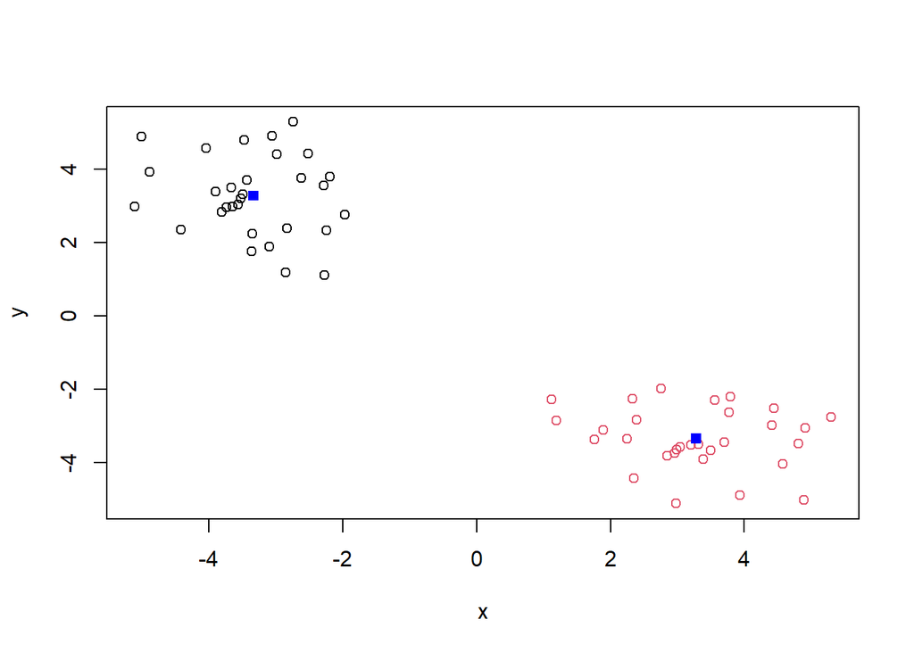

```r
plot(x, col = k$cluster)
points(k$centers, col ="blue", pch = 15)
```

## hclust() or Hierarchial Clustering

We will cluster the same data ‘x’ with hclust! In this case, hclust requires a distance matrix as input.

```r
hc <- hclust(dist(x))
hc
```

```
##
## Call:
## hclust(d = dist(x))
##
## Cluster method   : complete
## Distance         : euclidean
## Number of objects: 60
```

Let’s plot hclust result!

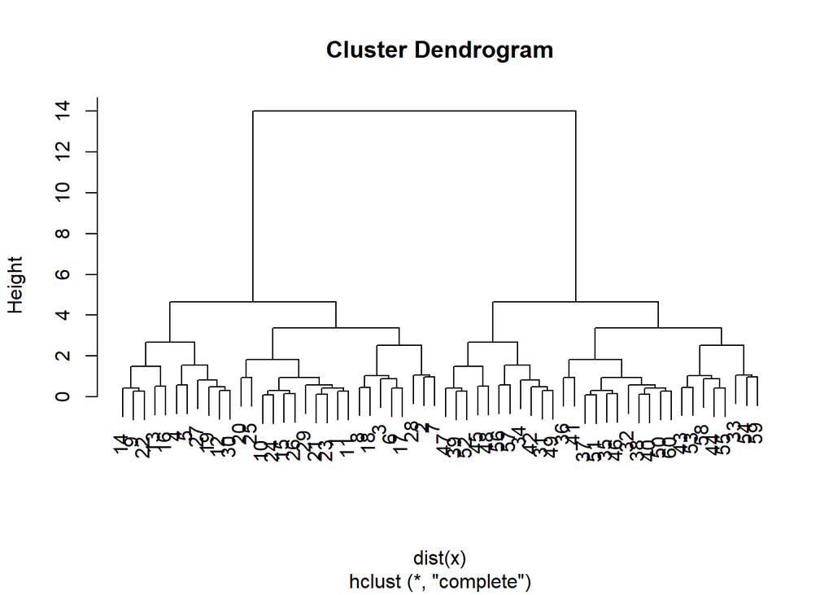

```r
plot(hc)
```

To get cluster membership vector we must “cut” tree with ‘cutree()’.

```r
grps <- cutree(hc, h = 8)
grps
```

```
##  [1] 1 1 1 1 1 1 1 1 1 1 1 1 1 1 1 1 1 1 1 1 1 1 1 1 1 1 1 1 1 1 2 2 2 2 2 2 2 2
## [39] 2 2 2 2 2 2 2 2 2 2 2 2 2 2 2 2 2 2 2 2 2 2
```

Now we plot our data with hclust results!

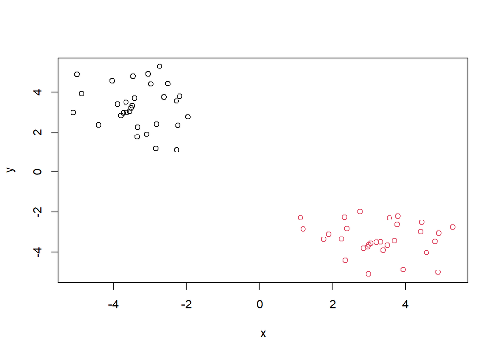

```r
plot(x, col=grps)
```